# 手写数字识别

## 逻辑回归手写数字识别

##### 基于Tensorflow 实现 softmax 的手写数字识别。

分别用单层网络、双层网络进行了识别测试，两次效果接近，但是双层网络收敛更快

训练集是机器学习的‘Hello World’—— MNIST。

##### 关于 MNIST

官网：http://yann.lecun.com/exdb/mnist/

这个MNIST数据库是一个手写数字的数据库，它提供了六万的训练集和一万的测试集。

它的图片是被规范处理过的，是一张被放在中间部位的28px*28px的灰度图

```python
import tensorflow as tf
import numpy as np

# 导入 MNIST 数据集，一共 55000 个样本
from tensorflow.examples.tutorials.mnist import input_data
mnist = input_data.read_data_sets("MNIST/mnsit", one_hot=True)
```

```
Extracting MNIST/mnsit\train-images-idx3-ubyte.gz
Extracting MNIST/mnsit\train-labels-idx1-ubyte.gz
Extracting MNIST/mnsit\t10k-images-idx3-ubyte.gz
Extracting MNIST/mnsit\t10k-labels-idx1-ubyte.gz
```

```python
def create_parameters(batch_size):
    # 创建输入
    X = tf.placeholder(tf.float32,[None,784]) # mnist 图片是 28*28=784 像素的
    Y = tf.placeholder(tf.float32,[None,10]) # 从 0-9 十个数字
    # 这里之所以前一个维度用 None ，是为了测试的时候不用再切分了

    # 创建权重
    W = tf.Variable(initial_value=tf.contrib.layers.xavier_initializer()(shape=(784,10)),dtype=tf.float32,name="W")
    b = tf.Variable(tf.zeros((1,10)),dtype=tf.float32,name="b")

    return X,Y,W,b
```

##### Xavier

Xavier初始化方法是一种很有效的神经网络初始化方法，上面没有用一般的 `np.random.randn` 为了使得网络中信息更好的流动，每一层输出的方差应该尽量相等，篇幅有限不详细展开。 而randn是均值为0方差为1的正态分布。 单层的话感觉两者没有太大区别。 当前这个实验来看，randn 和 Xavier最终的结果接近（0.9308,0.9318，测试多次，两个初始化基本没差别） 但是Xavier收敛更快，曲线更好看

`W = tf.Variable(initial_value=np.random.randn(784,10),dtype=tf.float32,name="W")`

下面这种就是一般的randn的初始化

```python
def prediction(X,W,b):
    # 创建正向预测
    pred = tf.nn.softmax(tf.matmul(X,W)+b)  # softmax 预测
    return pred

def compute_cost(Yhat,Y):
    # 计算成本函数
    # labels = tf.transpose(Y)   # 这里可能需要按照 tf 的要求做转置 tf.transpose(Y)
    labels = Y
    # logits = tf.transpose(Yhat)
    logits = Yhat
    cost = tf.reduce_mean(tf.nn.softmax_cross_entropy_with_logits(logits = logits, labels = labels))
    return cost
```

```python
def model(mnist,learning_rate = 0.01,training_epochs = 25,batch_size = 100,display_step = 1):
    # 整合各个步骤的执行函数
    # 执行训练
    # 准备阶段
    X,Y,W,b = create_parameters(batch_size)
    pred = prediction(X,W,b)
    cost = compute_cost(pred,Y)
    optimizer = tf.train.AdamOptimizer(learning_rate = learning_rate).minimize(cost)
    cost_list = []


    init = tf.global_variables_initializer()
    with tf.Session() as sess:
        sess.run(init)
        # 训练
        for epoch in range(training_epochs):                         # 训练总轮数
            batch_cost = 0
            total_batch = int(mnist.train.num_examples/batch_size)
            for i in range(total_batch):                             # 一轮有几个 mini batch（几次梯度下降）
                X_train,Y_train = mnist.train.next_batch(batch_size)
                _ , mini_cost = sess.run([optimizer, cost], feed_dict={X: X_train, Y: Y_train})

                batch_cost += mini_cost/total_batch
            print('Epoch:',epoch,'cost:',batch_cost)
            cost_list.append(batch_cost)
        print("训练完毕!")

        # 测试模型
        correct_prediction = tf.equal(tf.argmax(pred, 1), tf.argmax(Y, 1))
        # 计算准确性
        accuracy = tf.reduce_mean(tf.cast(correct_prediction, tf.float32))
        print("Accuracy:", accuracy.eval({X: mnist.test.images, Y: mnist.test.labels}))

        # cost图
        import matplotlib.pyplot as plt
        plt.plot(np.squeeze(cost_list),)
        plt.ylabel('cost')
        plt.xlabel('iterations (per tens)')
        plt.title("Learning rate =" + str(learning_rate))
        plt.show()
        return W,b # 保存训练参数
```

##### AdamOptimizer

Adam 是 动量梯度下降 和 RMSProp 的结合。

**动量梯度下降：** 因为每次权重跟新时，这次的梯度受到之前几次的梯度的影响，所以方向相反的更新的部分会抵消，方向相同的更新会加强。

**RMSProp：** 梯度变化较小的方向增大，梯度变化较大的方向变化减小。

两者都是减小了梯度下降过程中无谓的震荡，对梯度的跟新做了一定的约束，使其能够更快收敛

```
Epoch: 0 cost: 1.59341159625
Epoch: 1 cost: 1.54804588426
Epoch: 2 cost: 1.54117619645
Epoch: 3 cost: 1.5365169484
Epoch: 4 cost: 1.5339908045
Epoch: 5 cost: 1.53200336196
Epoch: 6 cost: 1.5300196795
Epoch: 7 cost: 1.52887040984
Epoch: 8 cost: 1.52747683395
Epoch: 9 cost: 1.52663213253
Epoch: 10 cost: 1.52583808357
Epoch: 11 cost: 1.52471973332
Epoch: 12 cost: 1.52385076978
Epoch: 13 cost: 1.52281232227
Epoch: 14 cost: 1.52200425647
Epoch: 15 cost: 1.52136109916
Epoch: 16 cost: 1.52146356691
Epoch: 17 cost: 1.52048356165
Epoch: 18 cost: 1.52019899932
Epoch: 19 cost: 1.51962334373
Epoch: 20 cost: 1.51863314975
Epoch: 21 cost: 1.51859026454
Epoch: 22 cost: 1.51850792668
Epoch: 23 cost: 1.51807426236
Epoch: 24 cost: 1.51744182045
训练完毕!
Accuracy: 0.9305
```

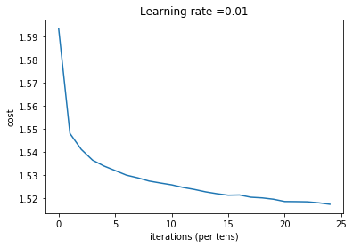

[output not shown]

```python
model(mnist)
```

#### 两层神经网络效果测试

```python
def create_parameters_twolayer(batch_size):  # 两层神经网络
    # 创建输入
    X = tf.placeholder(tf.float32,[None,784]) # mnist 图片是 28*28=784 像素的
    Y = tf.placeholder(tf.float32,[None,10]) # 从 0-9 十个数字
    # 这里之所以前一个维度用 None ，是为了测试的时候不用再切分了

    # 创建权重
    W1 = tf.Variable(initial_value=tf.contrib.layers.xavier_initializer()(shape=(784,30)),dtype=tf.float32,name="W1")
    b1 = tf.Variable(tf.zeros((1,30)),dtype=tf.float32,name="b1")
    W2 = tf.Variable(initial_value=tf.contrib.layers.xavier_initializer()(shape=(30,10)),dtype=tf.float32,name="W2")
    b2 = tf.Variable(tf.zeros((1,10)),dtype=tf.float32,name="b2")
    parameters = {
        'X':X,
        'Y':Y,
        'W1':W1,
        'b1':b1,
        'W2':W2,
        'b2':b2
    }
    return parameters
```

```python
def prediction_twolayer(X,Y,W1,b1,W2,b2):

    # 创建正向预测
    A1 = tf.nn.relu(tf.matmul(X,W1)+b1)
    pred = tf.nn.softmax(tf.matmul(A1,W2)+b2)  # softmax 预测
    return pred

def compute_cost_twolayer(Yhat,Y):
    # 计算成本函数
    # labels = tf.transpose(Y)   # 这里可能需要按照 tf 的要求做转置 tf.transpose(Y)
    labels = Y
    # logits = tf.transpose(Yhat)
    logits = Yhat
    cost = tf.reduce_mean(tf.nn.softmax_cross_entropy_with_logits(logits = logits, labels = labels))
    return cost
```

```python
def model_twolayer(mnist,learning_rate = 0.01,training_epochs = 25,batch_size = 100,display_step = 1):
    # 整合各个步骤的执行函数
    # 执行训练
    # 准备阶段
    parameters = create_parameters_twolayer(batch_size)
    X = parameters['X']
    Y = parameters['Y']
    pred = prediction_twolayer(**parameters)
    cost = compute_cost_twolayer(pred,parameters['Y'])
    optimizer = tf.train.AdamOptimizer(learning_rate = learning_rate).minimize(cost)
    cost_list = []
    # 改成两层神经网络之后，只有上面部分做了微调，这就是框架的好处。。。

    init = tf.global_variables_initializer()
    with tf.Session() as sess:
        sess.run(init)
        # 训练
        for epoch in range(training_epochs):                         # 训练总轮数
            batch_cost = 0
            total_batch = int(mnist.train.num_examples/batch_size)
            for i in range(total_batch):                             # 一轮有几个 mini batch（几次梯度下降）
                X_train,Y_train = mnist.train.next_batch(batch_size)
                _ , mini_cost = sess.run([optimizer, cost], feed_dict={X: X_train, Y: Y_train})

                batch_cost += mini_cost/total_batch
            print('Epoch:',epoch,'cost:',batch_cost)
            cost_list.append(batch_cost)
        print("训练完毕!")

        # 测试模型
        correct_prediction = tf.equal(tf.argmax(pred, 1), tf.argmax(Y, 1))
        # 计算准确性
        accuracy = tf.reduce_mean(tf.cast(correct_prediction, tf.float32))
        print("Accuracy:", accuracy.eval({X: mnist.test.images, Y: mnist.test.labels}))

        # cost图
        import matplotlib.pyplot as plt
        plt.plot(np.squeeze(cost_list),)
        plt.ylabel('cost')
        plt.xlabel('iterations (per tens)')
        plt.title("Learning rate =" + str(learning_rate))
        plt.show()
        return parameters # 保存训练参数
```

```
Epoch: 0 cost: 1.64433450872
Epoch: 1 cost: 1.56850407167
Epoch: 2 cost: 1.52135685054
Epoch: 3 cost: 1.51465454925
Epoch: 4 cost: 1.51066228086
Epoch: 5 cost: 1.51047693448
Epoch: 6 cost: 1.50650384318
Epoch: 7 cost: 1.50571605531
Epoch: 8 cost: 1.50410505165
Epoch: 9 cost: 1.5036522369
Epoch: 10 cost: 1.50297124993
Epoch: 11 cost: 1.50358327996
Epoch: 12 cost: 1.50260792082
Epoch: 13 cost: 1.49991451545
Epoch: 14 cost: 1.49921592452
Epoch: 15 cost: 1.49950075713
Epoch: 16 cost: 1.50031873595
Epoch: 17 cost: 1.49976621693
Epoch: 18 cost: 1.50013278636
Epoch: 19 cost: 1.5007540627
Epoch: 20 cost: 1.49802827033
Epoch: 21 cost: 1.49812306469
Epoch: 22 cost: 1.49927299304
Epoch: 23 cost: 1.50147599675
Epoch: 24 cost: 1.50207993876
训练完毕!
Accuracy: 0.9534
```

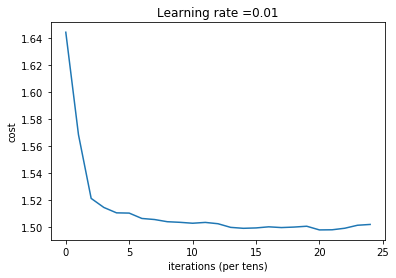

```python
parameters = model_twolayer(mnist)
```

```python
print(parameters)
```

[output not shown]

#### 双层网络最终效果稍微提升了一点（2%），但是整体来看收敛速度更快，

#### 训练最后阶段成本函数的波动，很可能是样本不同导致的拟合难度不同，也可能是出现了过拟合的现象。